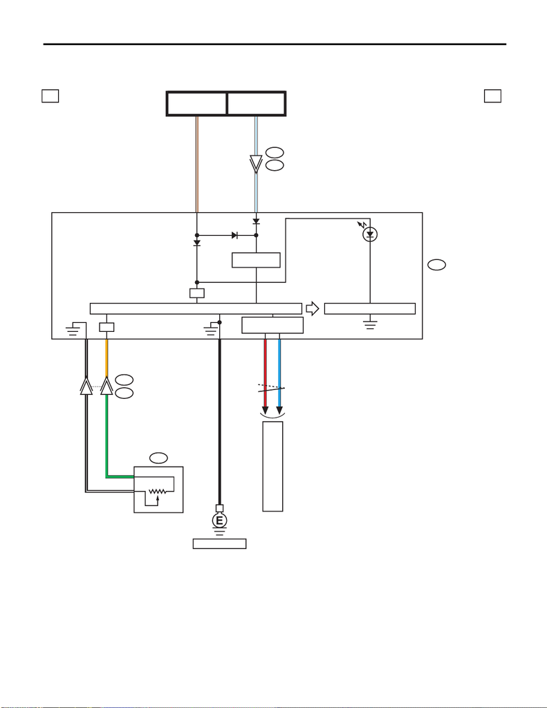

Rear Differential Oil Temperature Warning Light System

WIRING SYSTEM

42.Rear Differential Oil Temperature Warning Light System

A: WIRING DIAGRAM

3

WI-44540

I/F

I/F

R11

R339

i2

i10

i229

B551

20

40

BR/W

G

B/W

1

2

24O

34

B/W

G

B/W

38BB

33

32L

R

6

7

REAR DIFFERENTIAL

OIL TEMPERATURE

WARNING

FB-18

F/B FUSE NO. 7

(B)

FB-12

F/B FUSE NO. 2

(IG)

CAN TRANSCEIVER &

RECEIVER

MICRO COMPUTER

COMBINATION

METER

DRIVE CIRCUIT

REF. TO GND [e]

POWER SUPPLY

CIRCUIT

REAR DIFFERENTIAL

OIL TEMPERATURE

SENSOR

REF. TO CAN COMMUNICATION

SYSTEM [b]

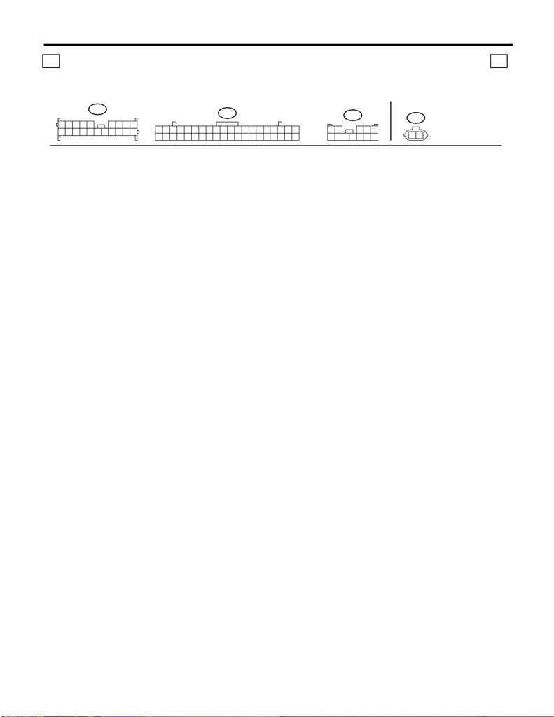

Rear Differential Oil Temperature Warning Light System

WIRING SYSTEM

WI-44541

b b

i229

6789

10 11 12

i10

11 12

9

10

2

18

20

21 22 23 24 26

25

27 28 29 30 31 32 33 34 35 36 37 38 39 40

17

i2

12345 6789

10 11 12 13 14 15 16 17 18 19 20

12

R11

(B)

LIST OF CONNECTORS